# geneScrapeR

## Functions

- Currently there are two funcitons in the package geneScrapeR
  - scrapeIDs
  - scrapeGenes
- scrapeIDs uses the package rentrez to search NCBI databases
- scrapeGenes uses the package pubmed.mineR to extract the genes from the publications

## rentrez

- rentrez searches NCBI databases within R
- Uses Entrez Utilities API
- [rentrez tutorial](https://ropensci.org/tutorials/rentrez_tutorial.html)

## pubmed.mineR

- Most of the functions in pubmed.mineR are used on abstracts downloaded from PubMed
- One exception, pubtator_function, contacts the PubTator website and extracts article information

## Using Downloaded Abstracts

[figure not shown]

## Using Downloaded Abstracts

```r
abstracts <- readabs('pubmed_result3.txt')

abstracts@PMID[1:5]
```

```
[1]       NA       NA 27720625 27638045       NA
```

```r
genes3 <- gene_atomization (abstracts)

genes3[3, ]
```

```
       Gene_symbol              Genes               Freq
              "CS" "citrate synthase"               "15"
```

## PubTator

- The pubmed.mineR function pubtator_function accesses the PubTator website
- This website allows us to extract the genes from each article
- [PubTator](https://www.ncbi.nlm.nih.gov/CBBresearch/Lu/Demo/PubTator/index.cgi?user=User237763554)

## PubTator Information

- From PubTator we have access to
  - Chemicals
  - Diseases
  - Genes
  - Mutation
  - Species
- pubtator_function also works with IDs from other databases from NCBI

## Workflow

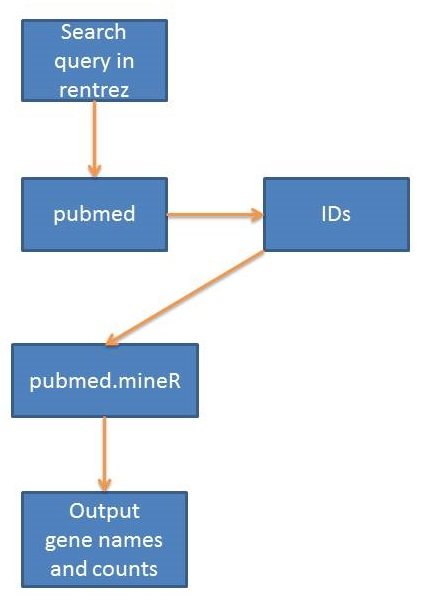

## scrapeIDs

```r
pmids <- scrapeIDs (dataBase = 'pubmed',
                    term = 'prostate cancer')
length(pmids)
[1] 146277

pmids[1:5]
[1] "28632693" "28632688" "28632505" "28632486" "28632242"

pmids2 <- scrapeIDs (dataBase = 'pubmed',
                     term = '"prostate cancer"')
length(pmids2)
[1] 93140

pmids2[1:5]
[1] "28632693" "28632688" "28632505" "28632486" "28631917"
```

## scrapeGenes

```r
genes <- scrapeGenes (IDs = pmids[1:500], nCores = 7, nTries = 5)

genes
```

```
# A tibble: 155 x 2
  geneNames     n
      <chr> <int>
1     ABCA1     1
2    ABCC10     1
3      AKT1     3
4      AKT2     1
5      AKT3     1
# ... with 150 more rows
```

## Plots

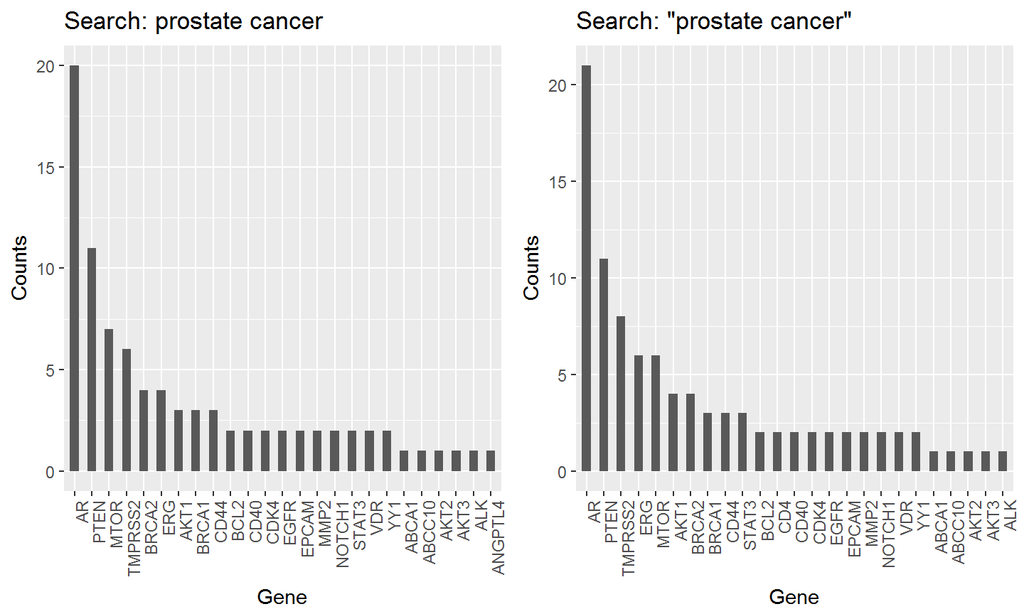

## NCBI Search Options

- Logical operators
  - AND: returns articles that match both terms
  - OR: returns articles that match either term
  - NOT: return articles that contain the left term but not the right term
- Fields
  - Organism, MeSH Terms, Date - Publication, Title/Abstract
  - To use fields enclose them in square brackets e.g. [Title/Abstract]
- You can find all available fields for each database with the advanced search option

## Search: Logical Operators

```r
malaria <- scrapeIDs (dataBase = 'pubmed',
                      term = '(vivax malaria[MeSH Terms]) AND
                      (folic acid antagonists[MeSH Terms])')
length (malaria)
```

```
[1] 12
```

```r
malaria2 <- scrapeIDs (dataBase = 'pubmed',
                       term = '(vivax malaria[MeSH Terms]) OR
                       (folic acid antagonists[MeSH Terms])')
length (malaria2)
```

```
[1] 8521
```

## Search: Fields

```r
alzheimer <- scrapeIDs (dataBase = 'pubmed',
                        term = 'alzheimer')
length (alzheimer)
```

```
[1] 92079
```

```r
alzheimer2 <- scrapeIDs (dataBase = 'pubmed',
                         term = 'alzheimer[MeSH Terms]')
length (alzheimer2)
```

```
[1] 77772
```

## MeSH Terms

From the NCBI website - MeSH (Medical Subject Headings) is the NLM controlled vocabulary thesaurus used for indexing articles for PubMed.

A list of other terms can be found on the NCBI website [here](https://www.ncbi.nlm.nih.gov/books/NBK3827/#pubmedhelp.Search_Field_Descriptions_and)